# Project: Investigate a Dataset - [No - show appointment]

- Introduction
- Data Wrangling
- Exploratory Data Analysis
- Conclusions

## Introduction

### Dataset Description

In this project we will be analysing the Appointments No-Show dataset, based on medical appointments in Brazil. We will investigate if there are any factors that influence the appointment attendance variable which is the independent variable. A number ofcharacteristics about the patient are included in each row.

- ‘ScheduledDay’ tells us on what day the patient set up their appointment.
- ‘Neighborhood’ indicates the location of the hospital.
- ‘Scholarship’ indicates whether or not the patient is enrolled in Brasilian welfare program Bolsa Família.
- 'No_show' says ‘No’ if the patient showed up to their appointment, and ‘Yes’ if they did not show up.

### Question(s) for Analysis

Upon careful study of the dataset, Here are some questions to be tackled:

- Fistly, which gender is more committed to showing up for appointments?
- Secondly,Do we have a specific age group with higher appointment show up rate?
- Thirdly, does receiving a scholarship have affect showing up for an appointment?
- For the fouth question, we want to investigte whether medical conditions have any impact attending appointments?
- Finally, Does receiving an sms reminder have impact on showing up for appointments?

```python
import pandas as pd
import numpy as np
import matplotlib.pyplot as plt
%matplotlib inline
```

## Data Wrangling

```python
# Loading the data and print out a few lines
df = pd.read_csv('NoShowAppointment.csv')
df.head()
```

|  | PatientId | AppointmentID | Gender | ScheduledDay | AppointmentDay | Age | Neighbourhood | Scholarship | Hipertension | Diabetes | Alcoholism | Handcap | SMS_received | No-show |
| --- | --- | --- | --- | --- | --- | --- | --- | --- | --- | --- | --- | --- | --- | --- |
| 0 | 2.987250e+13 | 5642903 | F | 2016-04-29T18:38:08Z | 2016-04-29T00:00:00Z | 62 | JARDIM DA PENHA | 0 | 1 | 0 | 0 | 0 | 0 | No |
| 1 | 5.589978e+14 | 5642503 | M | 2016-04-29T16:08:27Z | 2016-04-29T00:00:00Z | 56 | JARDIM DA PENHA | 0 | 0 | 0 | 0 | 0 | 0 | No |
| 2 | 4.262962e+12 | 5642549 | F | 2016-04-29T16:19:04Z | 2016-04-29T00:00:00Z | 62 | MATA DA PRAIA | 0 | 0 | 0 | 0 | 0 | 0 | No |
| 3 | 8.679512e+11 | 5642828 | F | 2016-04-29T17:29:31Z | 2016-04-29T00:00:00Z | 8 | PONTAL DE CAMBURI | 0 | 0 | 0 | 0 | 0 | 0 | No |
| 4 | 8.841186e+12 | 5642494 | F | 2016-04-29T16:07:23Z | 2016-04-29T00:00:00Z | 56 | JARDIM DA PENHA | 0 | 1 | 1 | 0 | 0 | 0 | No |

```python
# Lets check the shape of the dataset
df.shape
```

```
(110527, 14)
```

Our dataset has 110527 rows of appointments, with 14 Features

The column names of the datasets are difficult to read and contain typos, we will have to work on them (lower case and separated by underscores)

```python
# Checking for missing data and data types
df.info()
```

```
<class 'pandas.core.frame.DataFrame'>
RangeIndex: 110527 entries, 0 to 110526
Data columns (total 14 columns):
 #   Column          Non-Null Count   Dtype
---  ------          --------------   -----
 0   PatientId       110527 non-null  float64
 1   AppointmentID   110527 non-null  int64
 2   Gender          110527 non-null  object
 3   ScheduledDay    110527 non-null  object
 4   AppointmentDay  110527 non-null  object
 5   Age             110527 non-null  int64
 6   Neighbourhood   110527 non-null  object
 7   Scholarship     110527 non-null  int64
 8   Hipertension    110527 non-null  int64
 9   Diabetes        110527 non-null  int64
 10  Alcoholism      110527 non-null  int64
 11  Handcap         110527 non-null  int64
 12  SMS_received    110527 non-null  int64
 13  No-show         110527 non-null  object
dtypes: float64(1), int64(8), object(5)
memory usage: 11.8+ MB
```

We do not have any missing data within the dataset, it is however important to fix the data type of some columns:

- Let us change Scheduled Day / Appointment Day from a string to datetime
- We can change gender from a string to category like this (M: Male and F: Female)
- We can change no_show fom a string to an integer like this (1: Yes and 0: No)

```python
# Checking for duplicates
df.duplicated().sum(),df.duplicated('PatientId').sum(),df.duplicated('AppointmentID').sum()
```

```
(0, 48228, 0)
```

```python
# Finding summary statistics of our dataset
df.describe()
```

|  | PatientId | AppointmentID | Age | Scholarship | Hipertension | Diabetes | Alcoholism | Handcap | SMS_received |
| --- | --- | --- | --- | --- | --- | --- | --- | --- | --- |
| count | 1.105270e+05 | 1.105270e+05 | 110527.000000 | 110527.000000 | 110527.000000 | 110527.000000 | 110527.000000 | 110527.000000 | 110527.000000 |
| mean | 1.474963e+14 | 5.675305e+06 | 37.088874 | 0.098266 | 0.197246 | 0.071865 | 0.030400 | 0.022248 | 0.321026 |
| std | 2.560949e+14 | 7.129575e+04 | 23.110205 | 0.297675 | 0.397921 | 0.258265 | 0.171686 | 0.161543 | 0.466873 |
| min | 3.921784e+04 | 5.030230e+06 | -1.000000 | 0.000000 | 0.000000 | 0.000000 | 0.000000 | 0.000000 | 0.000000 |
| 25% | 4.172614e+12 | 5.640286e+06 | 18.000000 | 0.000000 | 0.000000 | 0.000000 | 0.000000 | 0.000000 | 0.000000 |
| 50% | 3.173184e+13 | 5.680573e+06 | 37.000000 | 0.000000 | 0.000000 | 0.000000 | 0.000000 | 0.000000 | 0.000000 |
| 75% | 9.439172e+13 | 5.725524e+06 | 55.000000 | 0.000000 | 0.000000 | 0.000000 | 0.000000 | 0.000000 | 1.000000 |
| max | 9.999816e+14 | 5.790484e+06 | 115.000000 | 1.000000 | 1.000000 | 1.000000 | 1.000000 | 4.000000 | 1.000000 |

Age column has a minumum value of -1 which does not make sense because we cant have a negative age and maximum value of 115 which I think, is too high. Thus, we will investigate for outliers and remove negative numbers.

### Data Cleaning

**Edit column names for readability and typos. Change to lowercase and separate by underscores.**

```python
df.columns.str.lower()
```

```
Index(['patientid', 'appointmentid', 'gender', 'scheduledday',
       'appointmentday', 'age', 'neighbourhood', 'scholarship', 'hipertension',
       'diabetes', 'alcoholism', 'handcap', 'sms_received', 'no-show'],
      dtype='object')
```

```python
# Edit columns manually
df.columns = ['patient_id', 'appointment_id', 'gender', 'scheduled_day',
       'appointment_day', 'age', 'neighbourhood', 'scholarship', 'hypertension',
       'diabetes', 'alcoholism', 'handicap', 'sms_received', 'no_show']
```

**Detect ouliers and remove negative numbers from the age column**

```python
# Lets define our interquartile range for the ages within the dataset

iqr = df['age'].quantile(0.75) - df['age'].quantile(0.25)

# Lets define our outlier threshold
outlier = df['age'].quantile(0.75) + 1.5 * iqr
print('Outlier Threshold: ', int(round(outlier, 0)))
```

```
Outlier Threshold:  110
```

```python
# Ages greater than the outlier threshold
df[df['age'] > 110]
```

|  | patient_id | appointment_id | gender | scheduled_day | appointment_day | age | neighbourhood | scholarship | hypertension | diabetes | alcoholism | handicap | sms_received | no_show |
| --- | --- | --- | --- | --- | --- | --- | --- | --- | --- | --- | --- | --- | --- | --- |
| 63912 | 3.196321e+13 | 5700278 | F | 2016-05-16T09:17:44Z | 2016-05-19T00:00:00Z | 115 | ANDORINHAS | 0 | 0 | 0 | 0 | 1 | 0 | Yes |
| 63915 | 3.196321e+13 | 5700279 | F | 2016-05-16T09:17:44Z | 2016-05-19T00:00:00Z | 115 | ANDORINHAS | 0 | 0 | 0 | 0 | 1 | 0 | Yes |
| 68127 | 3.196321e+13 | 5562812 | F | 2016-04-08T14:29:17Z | 2016-05-16T00:00:00Z | 115 | ANDORINHAS | 0 | 0 | 0 | 0 | 1 | 0 | Yes |
| 76284 | 3.196321e+13 | 5744037 | F | 2016-05-30T09:44:51Z | 2016-05-30T00:00:00Z | 115 | ANDORINHAS | 0 | 0 | 0 | 0 | 1 | 0 | No |
| 97666 | 7.482346e+14 | 5717451 | F | 2016-05-19T07:57:56Z | 2016-06-03T00:00:00Z | 115 | SÃO JOSÉ | 0 | 1 | 0 | 0 | 0 | 1 | No |

```python
# Ages with negative values
df[df['age'] < 0]
```

|  | patient_id | appointment_id | gender | scheduled_day | appointment_day | age | neighbourhood | scholarship | hypertension | diabetes | alcoholism | handicap | sms_received | no_show |
| --- | --- | --- | --- | --- | --- | --- | --- | --- | --- | --- | --- | --- | --- | --- |
| 99832 | 4.659432e+14 | 5775010 | F | 2016-06-06T08:58:13Z | 2016-06-06T00:00:00Z | -1 | ROMÃO | 0 | 0 | 0 | 0 | 0 | 0 | No |

```python
# Create a new data frame that covers positive ages to the outlier threshold
df = df[(df['age'] >= 0) & df['age'] <= 110]
df.shape
```

```
(110527, 14)
```

**Let us change the column name of the last column in the dataset which is 'no_show' to 'show_up', and convert the data to 0 and 1 instead of 'yes' and 'no', so that we can handle i using plot or groupby**

```python
# Change column name from 'no_show' to 'attended'
df.rename(columns = {'no_show': 'show_up'}, inplace = True)

# Replace 'yes' and 'no' with 0 and 1

df['show_up'].replace(['No', 'Yes'], [1, 0], inplace = True)
df.head(1)
```

|  | patient_id | appointment_id | gender | scheduled_day | appointment_day | age | neighbourhood | scholarship | hypertension | diabetes | alcoholism | handicap | sms_received | show_up |
| --- | --- | --- | --- | --- | --- | --- | --- | --- | --- | --- | --- | --- | --- | --- |
| 0 | 2.987250e+13 | 5642903 | F | 2016-04-29T18:38:08Z | 2016-04-29T00:00:00Z | 62 | JARDIM DA PENHA | 0 | 1 | 0 | 0 | 0 | 0 | 1 |

**We can now fix the data types of 'gender' to category and both 'scheduled_day' and 'appointment_day' to datetime**

```python
# Changing data types
df['gender'] = df['gender'].astype('category')
df['scheduled_day'] = pd.to_datetime(df.scheduled_day)
df['appointment_day'] = pd.to_datetime(df.appointment_day)
```

```python
df.info()
```

```
<class 'pandas.core.frame.DataFrame'>
Int64Index: 110527 entries, 0 to 110526
Data columns (total 14 columns):
 #   Column           Non-Null Count   Dtype
---  ------           --------------   -----
 0   patient_id       110527 non-null  float64
 1   appointment_id   110527 non-null  int64
 2   gender           110527 non-null  category
 3   scheduled_day    110527 non-null  datetime64[ns, UTC]
 4   appointment_day  110527 non-null  datetime64[ns, UTC]
 5   age              110527 non-null  int64
 6   neighbourhood    110527 non-null  object
 7   scholarship      110527 non-null  int64
 8   hypertension     110527 non-null  int64
 9   diabetes         110527 non-null  int64
 10  alcoholism       110527 non-null  int64
 11  handicap         110527 non-null  int64
 12  sms_received     110527 non-null  int64
 13  show_up          110527 non-null  int64
dtypes: category(1), datetime64[ns, UTC](2), float64(1), int64(9), object(1)
memory usage: 11.9+ MB
```

## Exploratory Data Analysis

### Let's first describe our data

```python
# Obtain proportions fot binary features, these are the features we will be using to analyse our data
bin_feat = ['scholarship', 'hypertension', 'diabetes', 'alcoholism', 'handicap',
       'sms_received', 'show_up']

df[bin_feat].mean().round(2)
```

```
scholarship     0.10
hypertension    0.20
diabetes        0.07
alcoholism      0.03
handicap        0.02
sms_received    0.32
show_up         0.80
dtype: float64
```

```python
# Proportion of male to females within the dataset
(df.groupby('gender').size()/ df.shape[0]).round(2)
```

```
gender
F    0.65
M    0.35
dtype: float64
```

From the data we can observe that:

- 10% of patients receive the scholarship
- 20% of patients suffer from hypertension
- 7% of patients have diabetes
- 3% of patients are alcoholics
- 2% of patients are handicap
- 30% of patients recieved a the sms reminder
- 80% of patients attended their appointments
- There are two times more female than male patients

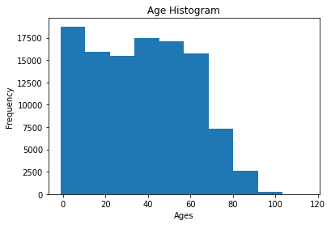

```python
# Age histogram

df['age'].plot(kind = 'hist', bins = 10)
plt.title('Age Histogram')
plt.xlabel('Ages');
```

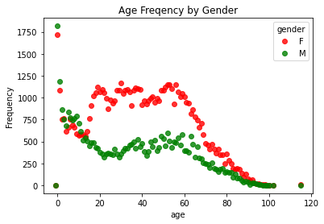

```python
# Plot the a crosstab for the gender of particular age ranges
pd.crosstab(df['age'], df['gender']).plot(style = ['or','og'], alpha = 0.8)
plt.title('Age Freqency by Gender')
plt.ylabel('Frequency');
```

The crosstab explains the second peak formed and that is due to the high frequency of females, where as the third peak has a contribution of both male and female, given thier proportions in the dataset

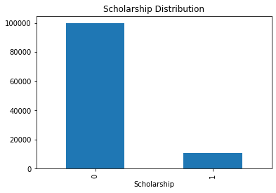

```python
df['scholarship'].value_counts().plot(kind = 'bar')
plt.title('Scholarship Distribution')
plt.xlabel('Scholarship');
```

The chart above shows the number of patients who received scholarships and patients who did not recieve scholarships.

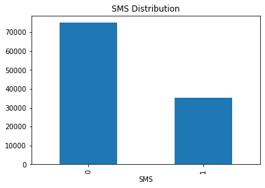

```python
df['sms_received'].value_counts().plot(kind = 'bar')
plt.title('SMS Distribution')
plt.xlabel('SMS');
```

The chart above shows the distribution of patients who received an sms and patients who did not recieve sms.

### Research Question 1 (Which gender is more committed to attending appointments?)

Let's create a generalized function to investigate the correlation between the specific variable and the final outcome(Show up or did not Show up).

The funtion will cross reference the desired variable against the final outcome, normalizing the result between 1-Show up and 0-Did and then plot a bar chart with titles and labels respectively.

```python
def showUp_proportion(feature):
    pd.crosstab(df[feature], df['show_up'], normalize = 'columns').plot(kind = 'bar', alpha = 0.85)
    plt.xlabel(f'Feature: {feature.replace("_", " ").title()}')
    plt.ylabel('Proportion')
    plt.title(f'Proportion of Attendance Rate by {feature.replace("_", " ").title()}')
    plt.margins(y = 0.1)
    return plt
```

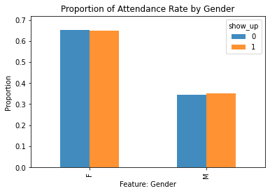

```python
# Does gender impact attendance?
showUp_proportion('gender');
```

We observe from this cross tab that the proportion of females who did not show up for their appointments are approximately the same as proportion of males who did not show up, so we cannot use gender as a yardstick tp know if a patient will show up at their appointments or not.

We can analyse further to understand the above graph:

```python
# Value counts of male and female who attended and those who did not attend their appointments
df.groupby('gender')['show_up'].value_counts().unstack()
```

| show_up gender | 0 | 1 |
| --- | --- | --- |
| F | 14594 | 57246 |
| M | 7725 | 30962 |

```python
# Precentage of male and female who attended and those who did not attend their appointments
df.groupby('gender')['show_up'].value_counts(normalize = True). mul(100).round(2).unstack()
```

| show_up gender | 0 | 1 |
| --- | --- | --- |
| F | 20.31 | 79.69 |
| M | 19.97 | 80.03 |

Gender does not have an influence on whether or not a patient is going to show up for a scheduled appointment as both male and female do not show up to aproximately 20% of their appointments

### Research Question 2 (Is there a specific age group with higher appointment show up rate?)

Let us transform the the ages into groups sice the distribution is widely spread out. it wouldn't look good on the graph. the age groups will represent 10th percentile of each.

```python
# Create a new column as age_groups to represent 10th percentile of the groups

df['age_groups'] = pd.qcut(df['age'], 10)
```

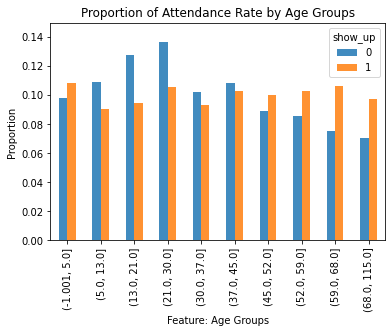

```python
# plot the crosstab for the age groups and proportions
showUp_proportion('age_groups');
```

From the above chat, we observe that patients between the ages of 5 years and 44 years seems less likely to show up for the appointment whereas patients patients older than 45 years seem to be more likely to attend the scheduled appointment. Another interesting observation is that patients less than 5 years tend to be slightly more likely to attend. We can see that age has influence on the attendance od scheduled appointments.

### Research Question 3 (Does Scholarship affect showing up at an appointments scheduled?)

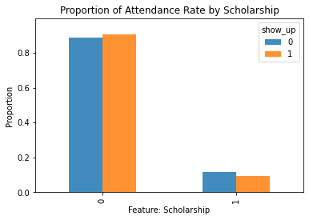

```python
showUp_proportion('scholarship');
```

From the graph we observe that patients that received scholarships seemmed less likely to attend the scheduled appointment as compared to patients who did not receive scholarships. Thus we can say there is a small but consistent difference in proportion of show up rate based on reception of scholarships.

### Research Question 4 ( Does medical conditions affect showing up to an appointments scheduled?)

Within our dataset we observed certain medical conditions like hypertension, diabetes, alcoholism and patients who are handicap. Do those medical conditions affect the show up rate for a scheduled appointment?

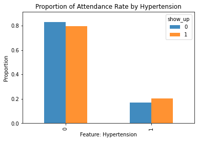

```python
# Plot a graph for hypetension patients
showUp_proportion('hypertension');
```

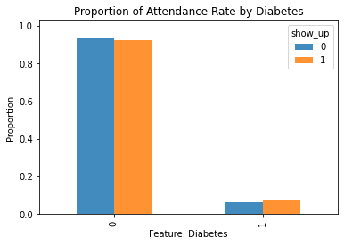

```python
# Plot a graph for diabetes patients
showUp_proportion('diabetes');
```

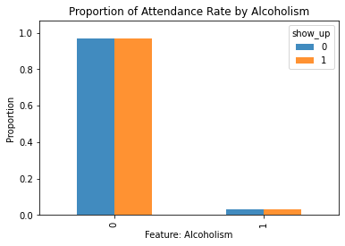

```python
# Plot a graph for alcoholic patients
showUp_proportion('alcoholism');
```

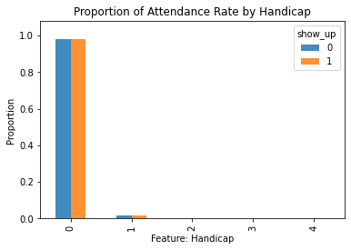

```python
# Plot a graph for handicap patients
showUp_proportion('handicap');
```

From the above four graphs, we observed that for patients with medical conditions like Hypertension and Diabetes, they are more likely to show up for the scheduled appointment where as patients with medical conditions alcoholism and handicap seem not not to have any impact on the show up rate for scheduled appointments.

### Research Question 5 (Does receiving an sms reminder have impact on patients showing up for the scheduled appointments?)

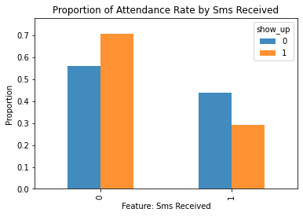

```python
# Proportion of those who received sms and those who did not together with their show up rate
showUp_proportion('sms_received');
```

Interesting!!!, patients who received sms were less likely to attend as compared to those who do not receive sms. Eventhough there is evidence that this feature impact the show up rate. It is however not reasonable that a patient would change their mind and not show up for an appointment after receiving an sms

## Conclusions

### Limitations

- The data did not contain useful features which will give sufficient information to derive the reasons behind patients showing up or not for appointments. Incorporation of the employment status of the patients could have been helpful since it could also have an impact on a patient showing up of the for the scheduled appointment or not.
- We observe an anormalous behaviour when we study patients who received sms and those who did not. And there is no exact cause for this, thus there is lack of explainability, which is a limitation to this dataset.

```python
from subprocess import call
call(['python', '-m', 'nbconvert', 'Investigate_a_Dataset.ipynb'])
```

```
4294967295
```